# The Algorithm to True Love

Alina Eckstein, Hossam Fahmy, Agnes Lei, Nathan Rohrbach (L1541695)

07.01.2022

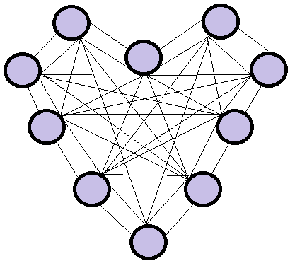

## 1 Use Case

Dating and matchmaking has always been one of the main quests in people’s lives. Finding the right partner for relationships, marriage or just an occasional rendez-vous, most times, is an ongoing trial-and-error process which comes with many disappointments, lengthy searches and hard feelings. Subsequently, many people prefer to make use of matchmaking services, apps and events to find a suitable partner faster, easier and more reliably. Thankfully, data can be used to simplify this whole process and predict a possible match.

### 1.1 Our Goal

In this project we want to visualize and predict possible matches of individuals, based on the forecast whether they will like each other or not. Therefore, we will analyze a speed dating data set. In doing so, we will apply different visualization and prediction methods which we learned in the Machine Learning class. The whole project will be implemented in an R Markdown file.

### 1.2 The Dataset

In this project we used one data set from a speed dating experiment with different variables on the participants self-assessment and assessment of their speed dating partners. The data set is linked and leads directly to the correct html page:

- [link](https://www.kaggle.com/annavictoria/speed-dating-experiment/data) This is the link to our data set. It contains 195 columns and 8’378 rows.

### 1.3 The Process

The process of this project will contain the following three main steps:

- First of all we will check the data for errors and make the necessary adjustments.
- Afterwards we will display and explore the processed data in various visualizations.
- In the last part we will create predictions by applying various forecasting and machine learning tools.

### 1.4 A Love Story

This project work aims to create a prediction model which can, based on its inputs, forecast whether two persons might like each other and be a possible match for further dating or not. Such a model can be used and applied in various dating apps, by matchmaking agencies or on speed dating events, increasing the success rate of the services they offer while spending less time, costs and effort to find and connect matching customers.

## 2 Data Preparation

### 2.1 Cleaning and Manipulation

The following steps were performed on the original dataset to prepare the data for our analysis and model fitting.

- Create new columns – same_field, same_origin by matching iid and pid
- Create new columns first_round (1 if the order = 1, 0 if order != 1) and last_round (the maximum order for each iid is found and compared to the order – 1 if max.order = order, 0 if max.orde =! order) These two columns are created because during data exploration, it was discovered that people met in the first or last round tend to like each other more. But since the number of rounds is not the same for all participants, we cannot just use the order itself as a variable.
- New column like_total is created as a potential response variable. This variable reflects the mutual affection rather than just one sided.
- All columns that we don’t need are dropped
- The columns which shouldn’t have non-integer are checked and the non-integers are replaced by NA
- Data type of factor variables are adjusted correctly
- Some columns are renamed for easier understanding
- All NAs dropped
- Reassign the factors to goal for better interpretation 0=other 1=To say I did it 2=fun night out 3=meet new people 4=get a date 5=serious relationship
- New column decision_count is added by counting the toal number of decision = 1 for each participant

### 2.2 Load All Packages Needed

First we load the packages needed for this project

```r
library(nnet)
library(neuralnet)
library(randomForest)
library(caret)
library(e1071)
require(lpSolve)
```

The final dataset contains the columns below

```r
names(speed.dating)
```

```
##  [1] "iid"            "match"          "pid"            "decision"
##  [5] "decision_count" "like"           "like_total"     "gender"
##  [9] "attr_self"      "sinc_self"      "fun_self"       "intel_self"
## [13] "amb_self"       "attr"           "sinc"           "intel"
## [17] "fun"            "amb"            "shar"           "goal"
## [21] "first_round"    "last_round"     "same_field"     "same_origin"
```

## 3 Graphical Analysis

In this section we perform various graphical analysis to examine the data. Using graphs and boxplots are an effective way to visualize data patterns and provides key insights into the data. This will help to understand the patterns and also the correlation between process parameters.

### 3.1 Data Exploration

We look into the distribution & relative frequency for Total like rating and number of mutual yes on decision count.

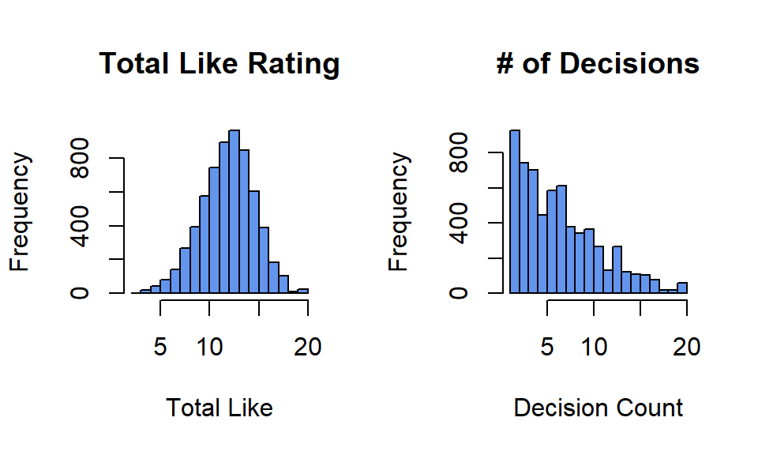

we notice that ‘like_total’ follows more of a normal distribution while ‘decision_count’ follows more of a binomial or Poisson distribution

### 3.2 Box Plots

Here we apply all the binary parameters / columns as factors and test their effect on the like rating and decision for a date

```r
cols <- c("gender","match","goal", "decision", "first_round", "last_round", "same_field", "same_origin")
d.dating[cols] <- lapply(d.dating[cols], factor)
```

The graphs below show effect of goals and gender on number of times a participant says yes to the partner.

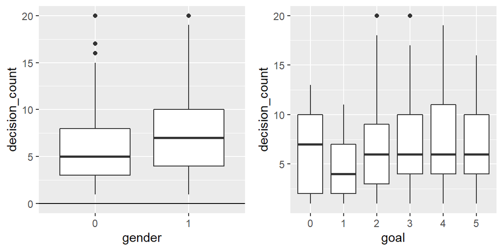

Note that with male (gender1) have higher count (maybe not as picky).

Next, we want to see whether two participants will like each other more when they are from the same field, origin or when they meet in the first round or last round.

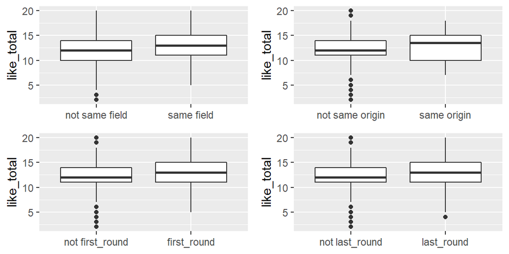

It seems that people tend to like each other more when they are from the same origin. For people from the same field and meet in the first or last round, they also tend to like each other a bit more. Yet, we can not judge whether there is a significant difference from the plots.

### 3.3 Correlation Matrix

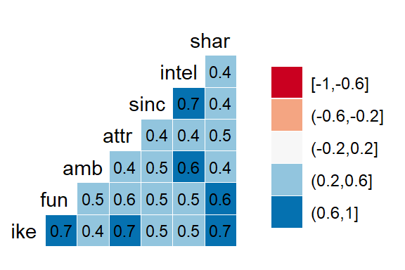

Note a strong correlation between like with funny, attractiveness & shared interests

## 4 Generalised Linear Model: Poisson and Binomial Distribution

In this section, we will apply the GLM model, using Poisson distribution on the variable ‘decision_count’ and using Binomial distribution on the ‘decision’ variable. We will draw a basic understanding of the ‘decision_count’ variables with the Poisson distribution. However, as predicting the variable ‘decision’ is the goal of this project, we will put greater effort in the GLM model with Binomial distribution, also known as Logistic Regression. As the first steps towards our goal to predict partner decision, we will talk about performance measurements and throw a cross validation.

### 4.1 GLM: Poisson Distribution

We use Poisson distribution to manipulate count data. Here, we will use ‘decision_count’ as our count data with decision count indicating the total number of yes per participant as in a partners’ mutual agreement to meet again.

#### 4.1.1 Poisson Analysis

Here we do some analysis to ensure that the decision_count as a variable is applicable to be evaluated with Poisson distribution. As we have seen in section 3.1 Data Exploration, the histogram has a relatively close follow of a poisson distribution. We also check mean and variance to determine whether it fits or if it is over/under-dispersion

#### 4.1.2 GLM: Poisson Model

We fit a Poisson model to the data and interpret the regression coefficients using the glm() function. Important: specify family=‘poisson’

```r
poisson.dating <- glm(decision_count~., family = "poisson", data = data.glm)
summary(poisson.dating)
```

After running the model, we determine from the residual deviance is about 12459 on 6261 degrees of freedom. If there was no overdispersion, we would expect the residual deviance to be about the same as degrees of freedom. We can therefore conclude that the model is overdispersed

#### 4.1.3 GLM: QuasiPoisson Model

When modelling count data, overdispersion is the rule not the exception. So now fit the quasipoisson model and look at the dispersion parameter.

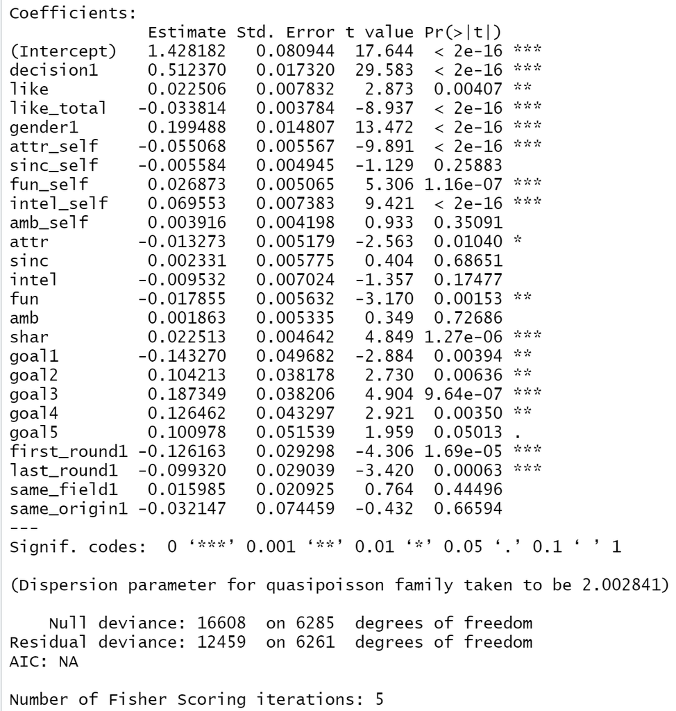

```r
quasipoisson.dating <- glm(decision_count~., family = 'quasipoisson', data = data.glm)
summary(quasipoisson.dating)
```

Comparing estimated regression coefficient and standard Error between both models in one table

```r
c.p = coef(poisson.dating)
c.qp = coef(quasipoisson.dating)
s.p = se.coef(poisson.dating)
s.qp = se.coef(quasipoisson.dating)
cbind(c.p,s.p,c.qp,s.qp)
```

```
##                       c.p         s.p         c.qp        s.qp
## (Intercept)   1.428182221 0.057195335  1.428182221 0.080943840
## decision1     0.512370370 0.012238153  0.512370370 0.017319649
## like          0.022506202 0.005534366  0.022506202 0.007832331
## like_total   -0.033814396 0.002673598 -0.033814396 0.003783723
## gender1       0.199487626 0.010462764  0.199487626 0.014807087
## attr_self    -0.055068299 0.003933956 -0.055068299 0.005567404
## sinc_self    -0.005583710 0.003493876 -0.005583710 0.004944595
## fun_self      0.026872620 0.003578727  0.026872620 0.005064677
## intel_self    0.069552675 0.005216666  0.069552675 0.007382718
## amb_self      0.003916162 0.002966223  0.003916162 0.004197850
## attr         -0.013273068 0.003659263 -0.013273068 0.005178653
## sinc          0.002331081 0.004080968  0.002331081 0.005775457
## intel        -0.009532384 0.004962980 -0.009532384 0.007023696
## fun          -0.017854808 0.003979506 -0.017854808 0.005631866
## amb           0.001863491 0.003769474  0.001863491 0.005334625
## shar          0.022513272 0.003280390  0.022513272 0.004642466
## goal1        -0.143270319 0.035105804 -0.143270319 0.049682348
## goal2         0.104213486 0.026976693  0.104213486 0.038177888
## goal3         0.187349235 0.026996443  0.187349235 0.038205838
## goal4         0.126462255 0.030593580  0.126462255 0.043296570
## goal5         0.100978393 0.036417967  0.100978393 0.051539345
## first_round1 -0.126162927 0.020701937 -0.126162927 0.029297744
## last_round1  -0.099320358 0.020519059 -0.099320358 0.029038932
## same_field1   0.015984821 0.014786041  0.015984821 0.020925465
## same_origin1 -0.032147267 0.052613253 -0.032147267 0.074459197
```

We notice that all the predictors that are significant to the ‘decision_count’ variable from the results of poisson and quasi-poisson models play a significant role in the models. We determined that using anova function.

```r
quasi.dating <- update(quasipoisson.dating, . ~ . - goal)
anova(quasipoisson.dating, quasi.dating, test = "F")
```

```
## Analysis of Deviance Table
##
## Model 1: decision_count ~ decision + like + like_total + gender + attr_self +
##     sinc_self + fun_self + intel_self + amb_self + attr + sinc +
##     intel + fun + amb + shar + goal + first_round + last_round +
##     same_field + same_origin
## Model 2: decision_count ~ decision + like + like_total + gender + attr_self +
##     sinc_self + fun_self + intel_self + amb_self + attr + sinc +
##     intel + fun + amb + shar + first_round + last_round + same_field +
##     same_origin
##   Resid. Df Resid. Dev Df Deviance      F    Pr(>F)
## 1      6261      12459
## 2      6266      12694 -5     -235 23.466 < 2.2e-16 ***
## ---
## Signif. codes:  0 '***' 0.001 '**' 0.01 '*' 0.05 '.' 0.1 ' ' 1
```

In this example we use goal and show that it has a strong evidence that it plays a role. We do similar procedure using other significant predictors (gender, like_total) and we get similar results.

Then finally we estimate a robust covariance matrix of parameters

```r
vcovHC(quasipoisson.dating, type='HC0')
```

As shown all the predictors with high significance p-values in quasipoisson GLM model, show strong evidences from anova test that they play a role when predicting the response variable decision_count

### 4.2 GLM: Binomial Distribution

We use Binomial distribution to manipulate binary and binomial data. Here, we will use binary data to predict the variable ‘decision’ (0 / 1). If a person is willing to see his/her partner again then it is a yes=1, otherwise it is a no=0.

In order to compare the model’s performance, we will split the data in training and testing set. We use the createDataPartition from the caret package with a split of 80% to training data and 20% testing data. This method hold the same proportion of response variable in both sets. For instance we know that there is 55% of ‘no’ and 45% of ‘yes’, this method of splitting data will hold this ratio in the training and testing set.

#### 4.2.1 Function: Model Evaluation

We created a function that evaluates the model performance as a confusion matrix. It takes the model prediction and round it to 0 or 1 depending if the probability is greater or lower than a certain threshold, so we can play with sensitivity, specificity and accuracy.

image:

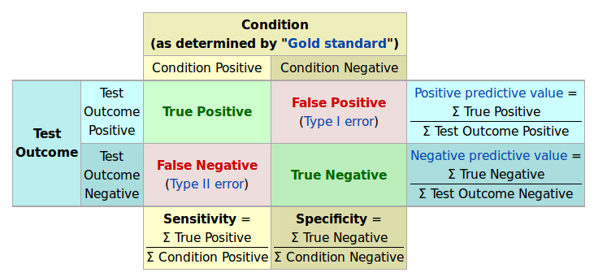

*source: HSLU, Machine Learning and Predictive Modeling, week 5*

**Accuracy:** middle point between Sensitivity and Specificity (threshold = 0.5)

**Sensitivity:** increase True Positive / decrease False Negative (threshold = 0.3) Probabilities greater than 30% will be considered as ‘yes’ (1), and probabilities under 30% will be considered as ‘no’ (0). *False Negative (Type II): predicting a ‘no’ when it’s a ‘yes’*

**Specificity:** increase True Negative / decrease False Positive –> threshold = 0.7 Probabilities greater than 70% will be considered as a ‘yes’ (1), and probabilities under 70% will be considered as ‘no’ (0). *False positive (Type I): predicting a ‘yes’ when it’s a ‘no’*

#### 4.2.2 Fit GLM Binomial Model 1: All Variable, no Interaction

We will first, fit a GLM model with binomial distribution, including all predictors and no interaction.

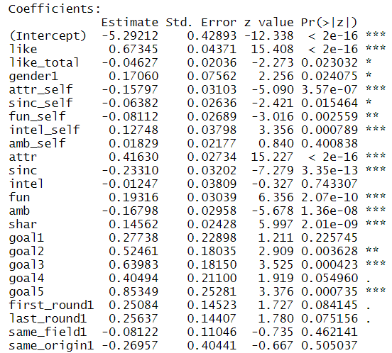

**Conclusion** As a medium complexity model (20 predictors, no interaction), the results are really good, with an overall accuracy of 78% with a threshold of 0.3. We have decided to observe the Sensitivity, that means increasing the True Positive and decreasing the False Negative. In other words, we want to improve the accuracy of prediction on ‘yes’ and reduce the number of wrong prediction ‘no’ when it’s a ‘yes’. The reason of this decision rely on the primary goal of the project, predicting a ‘match’. To have a ‘match’ the two partners need to give a ‘yes’, therefore if our prediction are accurate on the ‘yes’, we increase our chance of correctly predicting a ‘match’.

Mathematically:

$0*0=0=>NoMatch$

$0*1=0=>NoMatch$

$1*0=0=>NoMatch$

**$1*1=0=>Match$**

As you can see, the chance of a ‘match’ are lower. Plus the distribution of ‘yes’ is inferior to ‘no’ (45% of ‘yes’ and 55% of ‘no’). Therefore we need to improve the accuracy on True Positive.

**Problem:** We increase the False Positive (predicting a ‘yes’ when it’s a ‘no’), so we might predict more ‘match’ than in reality. (Our client are looking for meeting people, so if we give them more date than expected, is that a real problem?) The one possible issue, is to forecast a match when someone really didn’t like the partner so we need to ensure that the Specificity is not too low. (Specificity around 40% will be avoid)

#### 4.2.3 GLM Binomial Model 2: Interaction ‘Gender’

Now we will improve the model with interaction. One of our team member knows an expert in psychology, so he ask for background theory to understand decision process in partner selection. In relationship psychology, gender play a key role in partner selection. The theory states that Male pay more attention to physical appearance, so attractivity. On the other hand, Female look for social status, that means, intellectual potential, ambition and origin. Therefore, we will explore those interactions.

Let’s evaluate the performance of this new model

```
##           Reference
## Prediction   0   1
##          0 576 177
##          1 110 393
```

```
##  Accuracy [%] Sensitivity [%] Specificity [%]
##         77.15           68.95           83.97
```

The interactions with gender does not improve the model. That is problem with complex model, it can bring confusion to the model. We should perform a simpler model. First, we will interpret some of those result.

*Source:* * *Raymond Fisman, Sheena S. Iyengar, Emir Kamenica, Itamar Simonson, May 2006, “Gender Differences In Mate Selection:Evidence From a Speed Dating Experiment”* * *Mélanie Vanderschelden, 2006, “Position sociale et choix du conjoint : des différences marquées entre hommes et femmes”(french)* * *Kaufmann, 1993 Sociologie du couple, Paris: PUF, 5e édition 2010 (french)* * *Vincent SILENA, master student in psychology at the Lausanne University*

#### 4.2.4 Variable Interpretation

Due to the use of a link function, we must transform the coefficients to be able to interpret them. All the interpreted variables below are significant at a confidence level of 95% or 99% at least. We will start by a ‘self’ variable.

**Self rating attractivity (attr_self):**

```r
round(exp(coef(glm.model.2)['attr_self']),1)
```

```
## attr_self
##       0.9
```

**attractivity (attr):**

```r
round(exp(coef(glm.model.2)['attr']),1)
```

```
## attr
##  1.4
```

When increasing the attractivity score of your partner by 1, the odds increase by 40%. That means more attractive is your partner, more likely you willing to see him/her again (decision = ‘yes’). This variable is maybe one of the most important variable of the decision process in partner selection, we will it in further models (Random Forest).

#### 4.2.5 GLM Binomial Model 3: Simple Model

As we have seen before the model with interaction (complex model), does not yield better performance. Therefore, we will build a simple model, with 5 predictors, arbitrary selected. Then in the next section we will throw a Cross Validation to select the best model between the simple(5 predictors), the middle (20 predictors, no interaction), the complex (20 predictors, 4 interactions).

All predictors are significant at the maximum level of confidence (output not displayed)

```
##           Reference
## Prediction   0   1
##          0 582 176
##          1 104 394
```

```
##  Accuracy [%] Sensitivity [%] Specificity [%]
##         77.71           69.12           84.84
```

The simple model yields identical performance as the others. However, this result must be considered with precautions, as all models were build with the same training and testing set, therefore those result are not robust. We will throw a Cross Validation to evaluate the best model.

#### 4.2.6 Cross Validation

We will evaluate 3 different GLM models: simple (5 predictors), medium (20 predictors,no interaction), and complex (20 predictors with 4 interactions). We will split training and testing data 100 times with different splitting ratio(50/50,60/40, 70/30, 80/20, 90/10). The purpose of this manipulation is to evaluate which model is the more robust and also to determined the splitting ratio, which yield the best result. We will evaluate the model’s performances based on sensitivity and R-squared. R-squared is not a good measure for binary data, but we included for two reasons. First, to ensure a robust cross validation, we want to include another estimator. And R-squared is independent off the round-up operation made in the sensitivity calculations, set to 0.3 (confusion matrix).

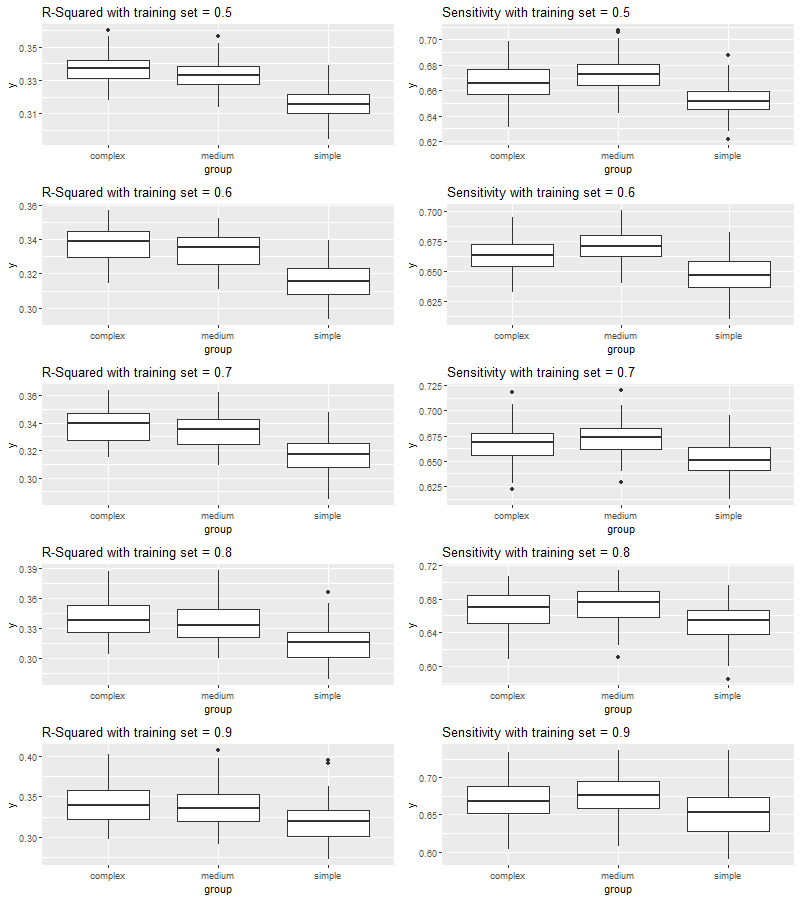

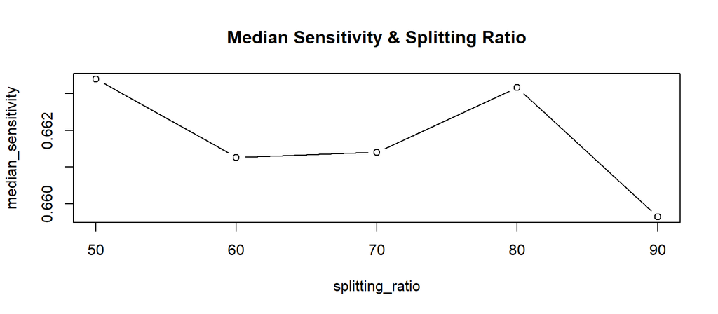

### 4.3 General Conclusion on GLM Model

**Pros GLM model:**

- *Simplicity*: easy to apply
- *Manipulation*: easy to manipulate, add and remove predictors
- *Knowledge*: easy to interpret the coefficients and help in data set understanding
- *Speed*: extremely fast

**Cons GLM model:**

- *Performance*: limited in complexity, so in performance

#### Performance summary

[output not shown]

**Best model:** GLM Binomial (20 predictors, no interaction)

## 5 Support Vector Machine

In this section we will apply the Support Vector Machine model as a classification method. We will use only the packages {e1071} and apply different kernel.

### 5.1 SVM e1071: Linear

We start with the linear kernel and a cost of 10 as basic model and then will improve it. We include the 20 predictors.

We have 2682 Number of support Vectors, that means SVM use half of the training sample to encode the training set. (We have 5030 observations in the training set)

Now, let’s evaluate the performance of this basic model with Confusion Matrix.

```
##           Reference
## Prediction   0   1
##          0 546 132
##          1 140 438
```

```
##  Accuracy [%] Sensitivity [%] Specificity [%]
##         78.34           76.84           79.59
```

Now we have two ways to improve the model. First with the Tune method, that tries several values for the cost C, or with Cross Validation we can apply similar improvements. We will apply this Cross Validation method, it generates a graph with accuracy performance and directly fit the improved model.

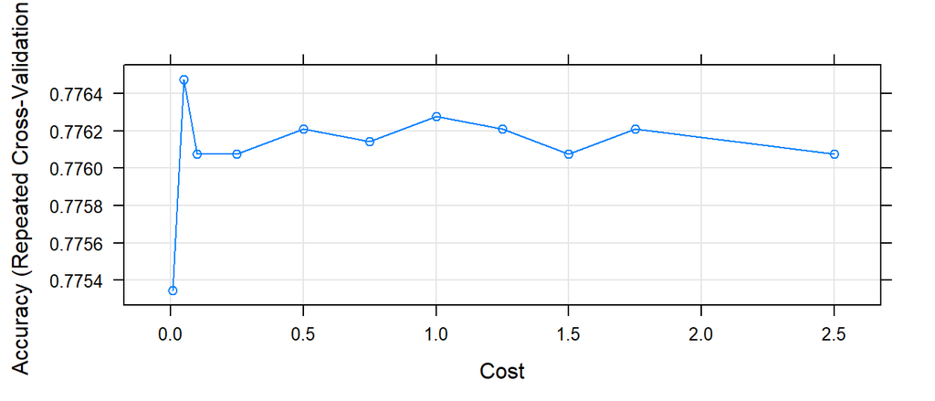

```r
set.seed(123)
trctrl <- trainControl(method='repeatedcv', number=10, repeats=3)
grid <- expand.grid(C=c(0,0.01,0.05,0.1,0.25,0.5,0.75,1,1.25,1.5,1.75, 2.5))
svm_linear_grid <- train(decision~., data=train, method='svmLinear',
                         trControl=trctrl,
                         preProcess=c('center','scale'),
                         tuneGrid=grid,
                         tuneLength=10)
plot(svm_linear_grid)
```

The optimal SVM model with linear kernel, according to cross validation is the model with a cost equal to 0.05 and here is the performance.

```
##           Reference
## Prediction   0   1
##          0 543 131
##          1 143 439
```

```
##  Accuracy [%] Sensitivity [%] Specificity [%]
##         78.18           77.02           79.15
```

Due to multiple predictors, it is hard to plot the model. We chose ‘like’ and ‘attractivity’ as those variables were extremely significative in the GLM model.

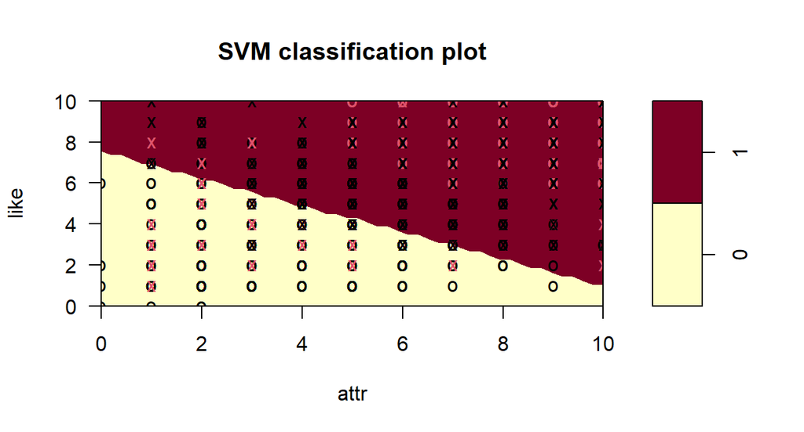

As you can see, the result of the splitting is visually not conclusive. Moreover, we see overlapping data, so maybe another kernel will be more adapted.

Let’s investigate the Radial model

### 5.2 SVM e1071: Radial

We will start with a basic model (cost=1 and gamma=1) and then observe the performance.

The Number of Support Vectors is 4955, that represent 98% of the training set. We should be careful with those results, they might be exposed to overfitting.

```
##           Reference
## Prediction   0   1
##          0 641 328
##          1  45 242
```

```
##  Accuracy [%] Sensitivity [%] Specificity [%]
##         70.30           42.46           93.44
```

As we can see the results are not as good as the linear kernel, plus the sensitivity is under 50%. We improved the model with the Tune function, we ran the code chunk with different value for cost and gamma. Accordingly, the optimal parameters are cost=1 and gamma=0.25.

The number of Support Vector Machine is 3464 lower than before, so the model is indeed improved and we reduce the overfitting risk.

```
##           Reference
## Prediction   0   1
##          0 566 125
##          1 120 445
```

```
##  Accuracy [%] Sensitivity [%] Specificity [%]
##         80.49           78.07           82.51
```

The overall accuracy is better than the previous model with radial kernel.

### 5.3 General Conclusion on Support Vector Machine

SVM model yield in overall very good result, slightly better than GLM model. We applied two different kernels, linear and radial. The linear kernel is very convenient due to its simplicity compared to the radial kernel. Hence, the processing time with linear kernel is shorter. There is still other kernel to apply and other packages to try. But according to our data, we think that applying SVM models is not optimal. As mention before, our data are mainly qualitative variables, and rely on subjective measures, therefore the data are exposed to noise (overlapping classes). It is hard for this algorithm to find a clear structure in such abstract process as partner selection (social psychology). Plus, SVM models do not provide probability estimates, hence we cannot build knowledge to help our clients in decision process or partner selection.

**Pros SVM model:**

- *Performance*: better than GLM models
- *Improvement*: easy to improve and different methods
- *Speed*: fast with our data set

**Cons SVM model:**

- *Overfitting*: high risk
- *Overlapping*: noisy data, unclear margin separation
- *No probability estimates*: interpretation not possible

#### Performance summary

| info | GLM | SVM Linear | SVM Radial |
| --- | --- | --- | --- |
| Accuracy: | 77.79 % | 78.18 % | **80.49 %** |
| Sensitivity: | 69.47 % | 77.02 % | **78.07 %** |
| Specificity: | **84.69 %** | 79.15 % | 82.51 % |

**Best model:** SVM radial (cost=1, gamma=0.25)

## 6 Neural Network

In this section we will apply Neural Network to our data set. Neural Network are an extremely powerful Machine Learning Algorithm used to build predictions. We will use different packages like {nnet}, {neuralnet} and {RandomForest} on the variable ‘decision’.

### 6.1 nnet

```r
#split data into train and test
set.seed(1)
index <- createDataPartition(data.nn$decision, p=.80, list = FALSE)

train <- data.nn[index,]
test <- data.nn[-index,]

#encoding categorical variable because nn needs each category to have its own column with dummy variable 0/1
train$gender = class.ind(train$gender)
train$goal = class.ind(train$goal)

test$gender = class.ind(test$gender)
test$goal = class.ind(test$goal)
```

We use a for loop to to find the optimal size

```r
#initialize variables
best_acc <- 0
size_best_acc <-0
best_sens <- 0
size_best_sens <- 0

#try size 1 to 20 to find best accuracy/ sensitivity
for (i in 1:20){
  set.seed(123)
  dating.net <- nnet(decision~ ., data = train, size=i, maxit=100, range=0.1, decay=5e-4) #fit model
  pred <- predict(dating.net, test, type = "class")
  nn <- table(pred=pred, true=test$decision)
  accuracy <- sum(diag(nn))/sum(sum(nn))
  sensitivity <- nn[1, 1]/(nn[1, 1] + nn[1, 2])
  if (accuracy > best_acc){
    best_acc <- accuracy
    size_best_acc <- i
  }
  if (sensitivity > best_sens){
    best_sens <- sensitivity
    size_best_sens <- i
  }
  }
```

```
##  Best accuracy 0.7906051  is from model with size = 10
##  Best sensitivity 0.8289902  is from model with size = 9
```

Since we would like to focus on sensitivity, the model with size = 9 is better. The model is as follows:

```r
dating.net <- nnet(decision~ ., data = train, size=9, maxit=100, range=0.1, decay=5e-4)
```

This neural network model includes 9 units in the hidden layer. This number of unit is chosen because it gives the best sensitivity when compared with models with 1 to 20 units.

```
##           Reference
## Prediction   0   1
##          0 536 150
##          1 115 455
```

[output not shown]

### 6.2 Random Forest

*Normalization (scaling) is not necessary for Random Forest and the algorithm support factors.*

Random Forest is a friendly machine learning algorithm with good result in classifications. We will explore this neural network and its features to catch variable importance and draw valuable conclusion for our customers, our business and other model improvements.

```
##           Reference
## Prediction   0   1
##          0 559 129
##          1 127 441
```

```
##  Accuracy [%] Sensitivity [%] Specificity [%]
##         79.62           77.37           81.49
```

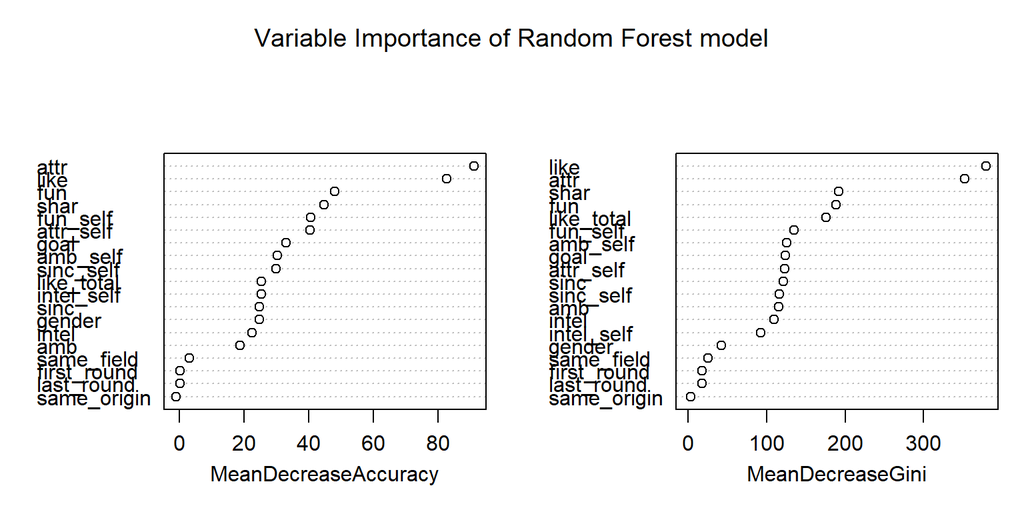

*MeanDecreaseAccuracy = decrease in accuracy if the variable is deleted* *MeanDecreaseGini = In classification model, the loss function is gini-impurity.It measure the decrease in loss function of the variable if deleted from the model.*

The three most important variables are ‘attractivity’, ‘like’ and ‘fun’. We have seen in the GLM models that all those predictors were significant at the maximum level of confidence. Therefore, our models are consistent with each other and we can confidently conclude the importance of those predictors. Let’s study how the behavior of the ‘attractivity’ variable on the decision process of a person.

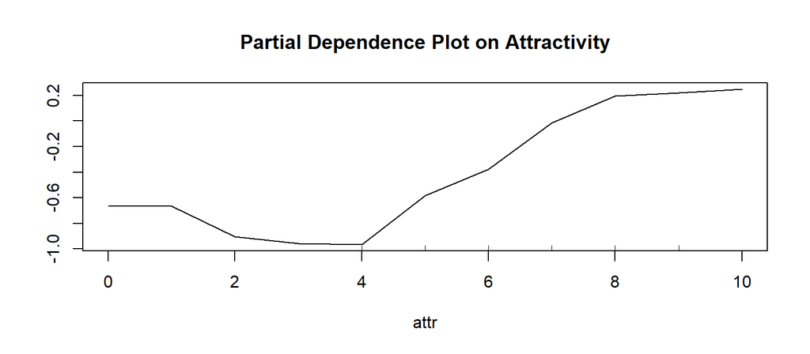

This graph tells us, that if someone rate his/her partner over 4 there is linearly increasing chance to say ‘yes’ for another date. Moreover, we can observe that grades 8 to 10 do not make a big difference. With those graph we gain valuable understanding on the decision process in partner selection. We can use those conclusion for customer coaching but also for business development, such as improving model’s performance. As you will see below…

### 6.3 neuralnet

*must contain only numeric values -> no factor* *recommended to normalized data, not required!*

We will use the package {neuralnet} as the neural network model but also as our best performing model. If we include all the predictors the model is extremely time consuming with more than one hidden layer (~20-30min). Therefore, we will train a simpler neural network (8 predictors instead of 20). To reduce the number of predictor and maximizing the model accuracy, there is a method called PCA, Principal Component Analysis. This is an advance concept so we will use the conclusion made in the other models, GLM, SVM and Random Forest. We have selected: ‘like’, ‘gender’, ‘attr_slef’ (personal score on attractivity), ‘fun_self’ (personal score on funny), ‘attr’ (grade partner on attractivity), ‘fun’ (grade partner score on funny), ‘shar’ (shared interest), ‘goal’ (reasons for speed dating)

```r
set.seed(123)
nn<-neuralnet(decision~., train, hidden=c(3,4,1),linear.output=FALSE,
              stepmax=50000, threshold = 0.05)
```

```
##           Reference
## Prediction   0   1
##          0 397  59
##          1 276 525
```

```
##  Accuracy [%] Sensitivity [%] Specificity [%]
##         73.35           89.90           58.99
```

*Disclaimer: Need to run a robust analysis, like a cross validation to confirm the model sensitivity is truly 90%, that it is not due to random effect.*

### 6.4 General Conclusion on Neural Network

Neural Network such as neuralnet have a huge potential in prediction performance, due to the unlimited complexity. However, those algorithm have 2 drawbacks. It is extremely time consuming when applied to big and complex data. It is also hard to understand and apply such algorithm without background knowledge in Machine Learning. Due to those issues, it is hard to take advantage of those multiple improvement combinations, even machine learning expert still have hard times understanding how to arrange hidden layers architecture. Despite, those difficulties, those models yield the best performance results.

**Pros NN model:**

- *Performance*: handle complex data structure and outperform GLM and SVM
- *Build Knowledge*: possibility to gain valuable information from NN models
- *Freedom*: infinite possibility of combination to improve models

**Cons NN model:**

- *Complexity*: hard to understand/improve, require a advanced knowledge
- *Slow*: time consuming

#### Performance summary

[output not shown]

**Best model:** Neuralnet (8 predictors, hidden layers=c(3,4,1))

## 7 Linear Model

In this part, we want to predict the response variable like_total, which is the sum of the rating from a participant and his/her partner on each other based on the question “Overall, how much do you like this person?”. The dataset is split into train(80%) and test(20%) with createDataPartition(). LM, Polynomials and GAM are fitted and their respective MAPEs are calculated to compare accuracy of the models.

### 7.1 Predictions on like_total

First we fit the linear model with like_total as the response variable and all other variables as predictors. Then use the drop1() function to test the predictors

```r
lm.like <- lm(like_total ~ ., data = train)
drop1(lm.like , test = "F")
```

```
## Single term deletions
##
## Model:
## like_total ~ attr_self + sinc_self + fun_self + intel_self +
##     amb_self + attr + sinc + intel + fun + amb + shar + goal +
##     first_round + last_round + same_field + same_origin
##             Df Sum of Sq   RSS    AIC  F value    Pr(>F)
## <none>                   21307 7295.5
## attr_self    1     52.01 21359 7305.7  12.2372 0.0004725 ***
## sinc_self    1      4.74 21312 7294.6   1.1158 0.2908778
## fun_self     1     22.31 21330 7298.7   5.2492 0.0219988 *
## intel_self   1     65.34 21373 7308.9  15.3735 8.939e-05 ***
## amb_self     1     17.45 21325 7297.6   4.1065 0.0427722 *
## attr         1    785.54 22093 7475.6 184.8135 < 2.2e-16 ***
## sinc         1    137.55 21445 7325.8  32.3606 1.353e-08 ***
## intel        1    229.91 21537 7347.5  54.0906 2.225e-13 ***
## fun          1    520.17 21828 7414.8 122.3801 < 2.2e-16 ***
## amb          1      3.55 21311 7294.3   0.8346 0.3609881
## shar         1   1363.34 22671 7605.4 320.7539 < 2.2e-16 ***
## goal         1     86.11 21394 7313.8  20.2592 6.916e-06 ***
## first_round  1     59.14 21367 7307.4  13.9141 0.0001935 ***
## last_round   1     18.55 21326 7297.9   4.3632 0.0367741 *
## same_field   1    111.06 21419 7319.6  26.1299 3.311e-07 ***
## same_origin  1      0.99 21308 7293.7   0.2325 0.6297103
## ---
## Signif. codes:  0 '***' 0.001 '**' 0.01 '*' 0.05 '.' 0.1 ' ' 1
```

```r
lm.like <- update(lm.like, . ~ . -sinc_self - fun_self
                                 - amb - same_origin)
summary(lm.like)$call
```

```
## lm(formula = like_total ~ attr_self + intel_self + amb_self +
##     attr + sinc + intel + fun + shar + goal + first_round + last_round +
##     same_field, data = train)
```

Compare predictions to test data and calculate MAPE

```r
pred.lm <- predict(lm.like, newdata = test)

mape <- mean(abs((pred.lm-test$like_total)/test$like_total)) * 100
cat("Mean absolute percentage error of the linear model is ", mape)
```

```
## Mean absolute percentage error of the linear model is  15.73033
```

Based on the model, let’s try to add interactions attr_self:attr and intel_self:intel

```r
lm.like.1 <- lm( like_total ~ attr_self*attr + intel_self*intel + amb_self +
                 sinc + fun + shar + goal + first_round + last_round +
                 same_field, data = train)

summary(lm.like.1)[4]
```

```
## $coefficients
##                      Estimate Std. Error    t value     Pr(>|t|)
## (Intercept)       6.161712572 1.09897647  5.6067739 2.171662e-08
## attr_self        -0.048108338 0.06786554 -0.7088772 4.784336e-01
## attr              0.081296508 0.07776952  1.0453518 2.959108e-01
## intel_self       -0.055846070 0.12496950 -0.4468776 6.549827e-01
## intel             0.280004226 0.14832488  1.8877765 5.911364e-02
## amb_self         -0.031728161 0.01728227 -1.8358790 6.643472e-02
## sinc              0.138115486 0.02374004  5.8178277 6.331506e-09
## fun               0.245493825 0.02219734 11.0596046 4.152668e-28
## shar              0.321197905 0.01782171 18.0228439 2.061513e-70
## goal             -0.128402100 0.02933096 -4.3776990 1.223782e-05
## first_round       0.439456172 0.11822454  3.7171317 2.036944e-04
## last_round        0.250392576 0.12164527  2.0583832 3.960491e-02
## same_field        0.458164106 0.08904470  5.1453271 2.772353e-07
## attr_self:attr    0.024497967 0.01036687  2.3631019 1.816063e-02
## intel_self:intel -0.008865983 0.01708721 -0.5188666 6.038766e-01
```

The result shows that there’s an interaction between attr_self and attr. Let’s update the model as follows:

```
## lm(formula = like_total ~ attr_self + intel_self + amb_self +
##     attr + sinc + intel + fun + shar + goal + first_round + last_round +
##     same_field + attr_self:attr, data = train)
```

We then calculate the MAPE to see if the value gets lower.

```r
pred.interact <- predict(lm.interact, newdata = test)

mape <- mean(abs((pred.interact-test$like_total)/test$like_total)) * 100
cat("Mean absolute percentage error of the linear model is ", mape)
```

```
## Mean absolute percentage error of the linear model is  15.68773
```

The result shows the predictions do improve slightly by adding the interaction to the model.

### 7.2 Residual Analysis

After fitting the model, we need to validate it by running some tests on the residuals to check whether the assumptions are true.

**Normality of the residuals**

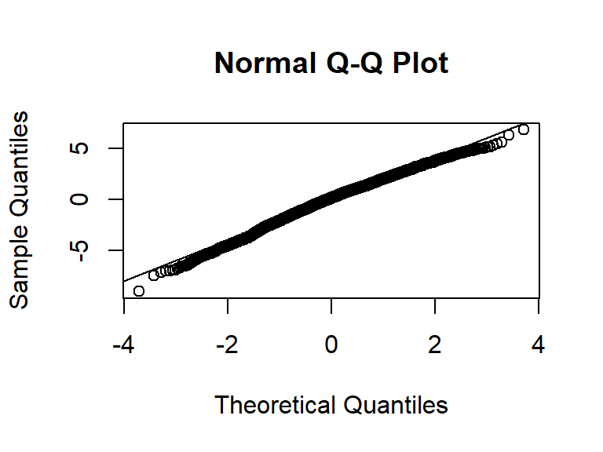

The residuals lay quite well on the reference line except a bit of deviation at the begining and end, indicating that the residuals follow a normal distribution.

**Check the mean of residuals and homoscedasticity**

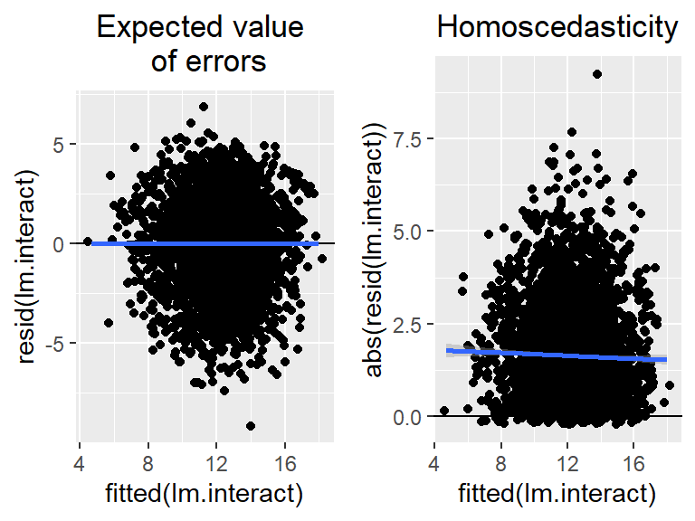

In the Tukey-Anscombe plot above, the smoother is on zero. Therefore, we may conclude that the assumption of “error on zero” is true.  
The right graph above confirms that the residuals seem to have a constant variance. The Linear Regression model seems to be valid as it passes all the diagnostic tests. Next, let’s try to use polynomials to see if the model can be improved.

### 7.3 Polynomials

**Plot each predictor against the response variable**

All non-categorical predictors are plotted against like_total

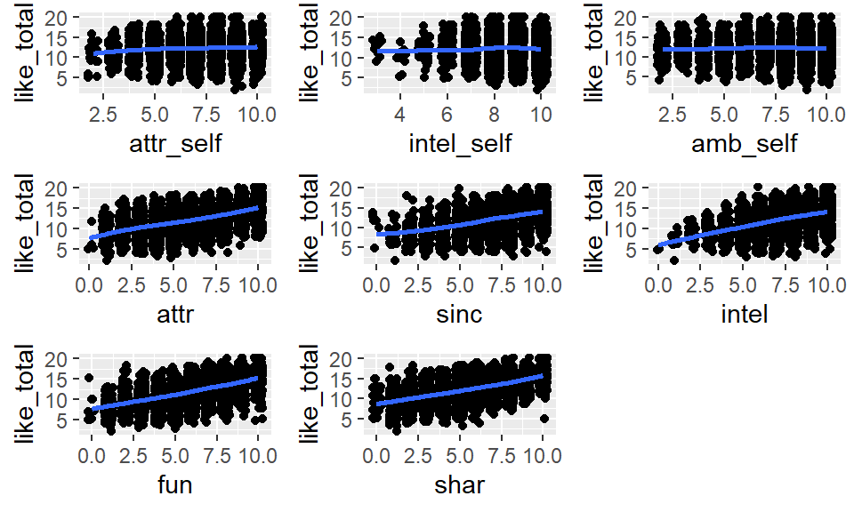

The plots show that all the predictors have a linear relationship to the response variable. Still, we try to add a quadratic effect to attr_self and check the result.

```
## $coefficients
##                                 Estimate Std. Error   t value      Pr(>|t|)
## (Intercept)                   6.36345009 0.28982339 21.956303 4.235415e-102
## intel_self                   -0.12281682 0.03050060 -4.026702  5.739969e-05
## amb_self                     -0.03041523 0.01727682 -1.760465  7.838990e-02
## attr                          0.25954815 0.01912584 13.570550  3.174249e-41
## sinc                          0.13519087 0.02370639  5.702718  1.246630e-08
## intel                         0.20424661 0.02665532  7.662509  2.174806e-14
## fun                           0.24839827 0.02220495 11.186618  1.034439e-28
## shar                          0.32150616 0.01781792 18.043981  1.438227e-70
## goal                         -0.13149069 0.02930252 -4.487352  7.372713e-06
## first_round                   0.43543767 0.11826064  3.682017  2.338300e-04
## last_round                    0.25110072 0.12167904  2.063632  3.910399e-02
## same_field                    0.45736023 0.08905134  5.135916  2.913970e-07
## poly(attr_self, degree = 2)1 10.18993412 2.29866654  4.432976  9.492461e-06
## poly(attr_self, degree = 2)2  2.23770853 2.07080887  1.080596  2.799287e-01
```

The summary of the new model confirms that there’s no quadratic effect on attr_self as the p-value. Therefore, it is not necessary to use polynomials here.

In the next part, we will try explore whether there are complex relationships in the data by using GAM.

## 8 GAM

We continue using the test and train datasets defined previously for LM model.

### 8.1 Fit GAM

Let’s fit a GAM to the train data by allowing non-linear, smooth effect on the coninuous prdictors.

```
##
## Family: gaussian
## Link function: identity
##
## Formula:
## like_total ~ gender + s(attr_self, k = 4) + s(intel_self, k = 4) +
##     s(amb_self, k = 4) + s(attr, k = 4) + s(sinc, k = 4) + s(intel,
##     k = 4) + s(fun, k = 4) + s(shar, k = 4) + goal + first_round +
##     last_round + same_field
##
## Parametric coefficients:
##              Estimate Std. Error t value Pr(>|t|)
## (Intercept)  12.16042    0.14596  83.316  < 2e-16 ***
## gender1      -0.14745    0.06081  -2.425 0.015354 *
## goal1         0.48617    0.18439   2.637 0.008398 **
## goal2         0.33489    0.14783   2.265 0.023530 *
## goal3        -0.06944    0.14880  -0.467 0.640772
## goal4        -0.18344    0.17289  -1.061 0.288729
## goal5         0.26439    0.21164   1.249 0.211640
## first_round1  0.43341    0.11752   3.688 0.000228 ***
## last_round1   0.24305    0.12093   2.010 0.044503 *
## same_field1   0.45375    0.08868   5.117 3.22e-07 ***
## ---
## Signif. codes:  0 '***' 0.001 '**' 0.01 '*' 0.05 '.' 0.1 ' ' 1
##
## Approximate significance of smooth terms:
##                 edf Ref.df       F  p-value
## s(attr_self)  2.881  2.988   8.041 3.22e-05 ***
## s(intel_self) 2.859  2.983   9.637 5.64e-06 ***
## s(amb_self)   1.000  1.000   3.668   0.0555 .
## s(attr)       2.293  2.661  78.390  < 2e-16 ***
## s(sinc)       1.000  1.000  32.432  < 2e-16 ***
## s(intel)      1.000  1.000  50.924  < 2e-16 ***
## s(fun)        1.000  1.000 125.700  < 2e-16 ***
## s(shar)       1.000  1.000 329.034  < 2e-16 ***
## ---
## Signif. codes:  0 '***' 0.001 '**' 0.01 '*' 0.05 '.' 0.1 ' ' 1
##
## R-sq.(adj) =  0.435   Deviance explained = 43.8%
## GCV = 4.2174  Scale est. = 4.1981    n = 5030
```

The summary output shows that only attr_self, intel_self and attr have non-linear effects between quadratic and cubic on like_total. And amb_self doesn’t have a significant effect on the response variable in this model.

### 8.2 Refit Model

Now we refit the model according to findings from the summary output.

```
## like_total ~ gender + s(attr_self, k = 4) + s(intel_self, k = 4) +
##     s(attr, k = 4) + sinc + intel + fun + shar + goal + first_round +
##     last_round + same_field
```

Compare predictions to test data and calculate MAPE

```r
pred.gam <- predict(gam.like, newdata = test)

mape <- mean(abs((pred.gam - test$like_total)/test$like_total)) * 100
```

```
## Mean absolute percentage error of the model is  15.71625
```

### 8.3 Comparison of Models and Conclusion

We can see from the table below that the three models have very similar results.

|  | MAPE |
| --- | --- |
| LM | 15.68773 |
| Polynomials | 15.72326 |
| GAM | 15.71625 |

The Linear Model shown below has the lowest MAPE.

```
## like_total ~ attr_self + intel_self + amb_self + attr + sinc +
##     intel + fun + shar + goal + first_round + last_round + same_field +
##     attr_self:attr
```

Below are the coefficients of the model.

```
##                   Estimate Std. Error    t value     Pr(>|t|)
## (Intercept)     6.29462435 0.53752307 11.7104264 2.870191e-31
## attr_self      -0.05945659 0.06710990 -0.8859585 3.756824e-01
## intel_self     -0.11301552 0.03061638 -3.6913417 2.254449e-04
## amb_self       -0.03542209 0.01728814 -2.0489246 4.052145e-02
## attr            0.08255489 0.07692542  1.0731809 2.832416e-01
## sinc            0.13422942 0.02368218  5.6679502 1.525977e-08
## intel           0.20498383 0.02658502  7.7105002 1.501579e-14
## fun             0.24553780 0.02212748 11.0965083 2.778584e-28
## shar            0.32449496 0.01776490 18.2660690 3.247444e-72
## goal1           0.48956641 0.18440368  2.6548625 7.959158e-03
## goal2           0.32268800 0.14781609  2.1830370 2.907933e-02
## goal3          -0.07472594 0.14876851 -0.5022967 6.154809e-01
## goal4          -0.23162359 0.17244178 -1.3431987 1.792684e-01
## goal5           0.27681263 0.21203242  1.3055203 1.917757e-01
## first_round1    0.43494413 0.11778320  3.6927520 2.242013e-04
## last_round1     0.24501259 0.12121186  2.0213582 4.329575e-02
## same_field1     0.46541735 0.08874907  5.2441939 1.634198e-07
## attr_self:attr  0.02482692 0.01024383  2.4235978 1.540279e-02
```

**Interpretation of Linear Model**:

## 9 Conclusion

### 9.1 A Function to Predict Match

The ultimate goal of our model is to successfully match people who like each other. Therefore,a function is created to predict matches by comparing the predicted decisions made by two participants.

```r
match_prediction <- function(dataset, model, pred_type=c("response", "terms"))
                    {
                dataset$pred_decision <- predict(model, dataset, type = pred_type)
                pred_df <- dataset %>%
                mutate(pair_number = case_when(iid < pid ~ paste(iid,"&",pid),
                                     (pid < iid ~ paste(pid,"&",iid))))%>%
                group_by(pair_number) %>%
                filter(n()>1)%>%
                group_by(pair_number) %>%
                mutate(pred_decision = as.numeric(as.character(pred_decision)))%>%
                mutate(pred_match = prod(pred_decision)) %>%
                distinct(pair_number, .keep_all = TRUE) %>%
                dplyr::select(c(pair_number, match, pred_match))

                pred_df
                    }
```

As a demonstration, we choose to apply nnet to the function as its prediction is more straightforward.

```r
set.seed(123)
dating.net <- nnet(decision~ ., data = train , size=9, maxit=100, range=0.1, decay=5e-4)
```

```r
#apply match_prediciton function
nnet_match <- (match_prediction(test, dating.net, "class"))

head(nnet_match)
```

```
## # A tibble: 6 x 3
## # Groups:   pair_number [6]
##   pair_number match pred_match
##   <chr>       <int>      <dbl>
## 1 1 & 12          0          1
## 2 1 & 18          0          0
## 3 7 & 14          1          1
## 4 9 & 18          0          0
## 5 21 & 46         0          0
## 6 21 & 54         0          0
```

```r
nnet_match_accuracy <- sum(nnet_match$match == nnet_match$pred_match)/nrow(nnet_match)
cat("The match prediction accurarcy is ", round(nnet_match_accuracy*100,2), "%")
```

```
## The match prediction accurarcy is  81.73 %
```

Hence, we have been able to predict the match and verify the accuracy of the forecast.

### 9.2 General Conclusion

Whether it is on dating apps, using the help of agencies or in real life – finding the right partner for a relationship is always a difficult task. With this project we aimed to simplify this quest by creating a model which can predict whether two people would likely be a good match or not. With the help of data from a speed dating event we wanted to find the right variables on which we could base the forecasting algorithm. Such a model would be of tremendous benefit for all companies, events and agencies focusing on matchmaking, as it can automate the service process and help finding the right partner match for clients in a much faster, cheaper, and easier way.

Based on the dataset that we used, we understood that by predicting the variable “decision”, which represented whether a person wanted to meet their dating partner again or not, it would allow us to identify matches between two persons, given that the decision on both parts would be a “yes”. Therefore, the applied forecasting methods were aimed to predict this variable. The models which allowed us to develop a successful prediction were the GLM, SVM, and Neural Network model.

Starting with the GLM model, we applied three simulations: * Simple model with 5 predictors * Medium complex model with 20 predictors * Complex model with 20 predictors and 4 interactions

The medium complex model turned out to be the best performing one. The more important result, however, was the knowledge that we gained by identifying and analysing interactions, significance, and effects of various predictors. Hence, we were able to better understand the human psychology behind the partner selection process. We then used the gained knowledge in the other forecasting models (SVM and NN) which helped us to achieve a higher success rate.

When applying the SVM model, we found it more difficult to develop a good forecast due to the subjective nature of our data, given that it is heavily based on qualitative measures and human behaviour, which is highly abstract and therefore hard to classify or predict.

With this, we have achieved our goal and created a Neural Network model which predicts the decision of persons whether they would want to meet their counterpart again or not and, therefore, whether two persons can be a match or not. We believe that this model can be of great help in the realm of matchmaking and will be a very useful tool for creating new Love Stories.

## 10 Optimization

Optimization is a technique used in many spheres to mathematically help finding the best solution to a given problem, out of all possible options. For this, the problem must be formulated in mathematical term and thus three factors must be identified:

- Objective
- Control Variable
- Constraints

### 10.1 Example

A big matchmaking agency wants to maximize its profits for two service offerings “Finding your Love” and “Predicting your Chances” which are sold at 33CHF and 28CHF, respectively. There are 1150 employees available every day and service “Finding your Love” requires 13 employees while “Predicting your Chances” requires 11 employees. Service “Finding your Love” requires 5 minutes of process time, “Predicting your Chances” requires 6 minutes, and there are only 8 working hours in a day. How many of each services should be processed to maximize profits?

```r
# setting the coefficients of the objective function
objective <- c(33, 28)

# setting the constraint
A <- matrix(c(13, 11, 5, 6, 1, 0, 0, 1),
            nrow=4, byrow=TRUE)             # constraint coefficients
b <- c(1150, 480, 0, 0)                       # constraint rhs
dir  <- c("<=", "<=", ">=", ">=")             # direction of inequality

optimum <-  lp(direction="max",  objective, A, dir,  b)

cat("The optimal value is", optimum$objval, "\n")
```

```
## The optimal value is 2920.87
```

```r
cat("The optimal solution is (x,y) = (", optimum$solution, ")")
```

```
## The optimal solution is (x,y) = ( 70.43478 21.30435 )
```

Hence, the maximal profit of roughly 2920 CHF can be achieved by processing 70 “Finding your Love” and 21 “Predicting your Chances” services per day.